# Forecasting

Jeffrey Leek, Assistant Professor of Biostatistics

## Time series data

[figure not shown]

https://www.google.com/finance

## What is different?

- Data are dependent over time
- Specific pattern types
- Trends - long term increase or decrease
- Seasonal patterns - patterns related to time of week, month, year, etc.
- Cycles - patterns that rise and fall periodically
- Subsampling into training/test is more complicated
  - specific times must be sampled
  - points are dependent in time.
- Similar issues arise in spatial data
- Dependency between nearby observations
- Location specific effects
- Typically the goal is to predict one or more observations into the future.
- All standard predictions can be used (with caution!)

## Beware spurious correlations!

Time series can often be correlated for reasons that do not make them good for predicting one from the other.

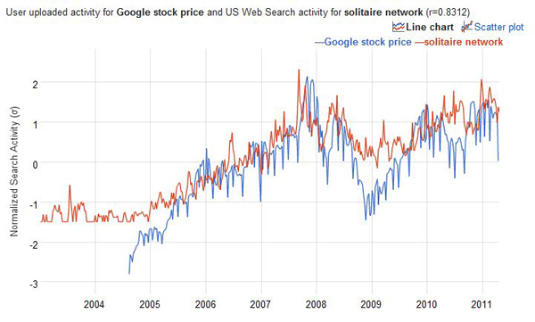

Here we see that the Google stock price correlates very well with the solitaire network for the given period. Yet they are not related in any way, so there is no reason for them correlate in the future.

http://www.google.com/trends/correlate

http://www.newscientist.com/blogs/onepercent/2011/05/google-correlate-passes-our-we.html

## Also common in geographic analyses

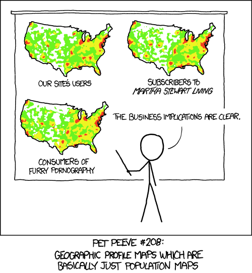

http://xkcd.com/1138/

## Beware extrapolation!

Here we see the winning time of many Olympic races exptrapolated into the future. The blue are men and the red are women. But this extrapolation taken to its logical extreme predicts that races will be run in negative times!

The point is that an exptrapolation is only good for limited time into the future.

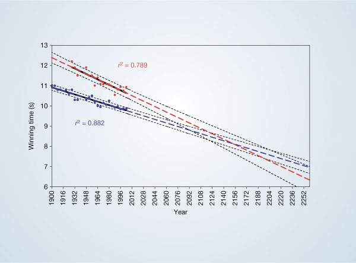

http://www.nature.com/nature/journal/v431/n7008/full/431525a.html

## Google data

```r
library(quantmod)
from.dat <- as.Date("01/01/08", format="%m/%d/%y")
to.dat <- as.Date("12/31/13", format="%m/%d/%y")
getSymbols("GOOG", src="google", from = from.dat, to = to.dat)
```

```
[1] "GOOG"
```

```r
head(GOOG)
```

```
           GOOG.Open GOOG.High GOOG.Low GOOG.Close GOOG.Volume
2008-01-02     346.1     348.3    338.5      342.2          NA
2008-01-03     342.3     343.1    337.9      342.3          NA
2008-01-04     339.5     340.1    327.2      328.2          NA
2008-01-07     326.6     330.8    318.4      324.3          NA
2008-01-08     326.2     329.6    315.2      315.5          NA
2008-01-09     314.7     326.3    310.9      326.3          NA
```

## Summarize monthly and store as time series

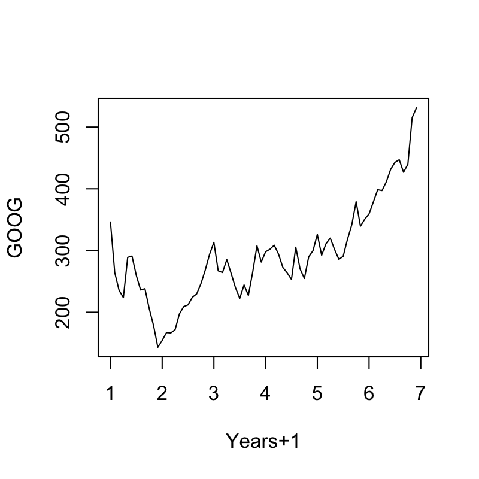

```r
# In this case, the 'Volume' data in GOOG has NAs
GOOG <- subset(GOOG, select = -GOOG.Volume)
# so eliminating 'Volume' solves that for this example.
mGoog <- to.monthly(GOOG)
googOpen <- Op(mGoog)
ts1 <- ts(googOpen,frequency=12)
plot(ts1,xlab="Years+1", ylab="GOOG")
```

## Example time series decomposition

- **Trend** - Consistently increasing pattern over time
- **Seasonal** - When there is a pattern over a fixed period of time that recurs.
- **Cyclic** - When data rises and falls over non fixed periods

https://www.otexts.org/fpp/6/1

## Decompose a time series into parts

The `decompose()` function is from the ‘stats’ package

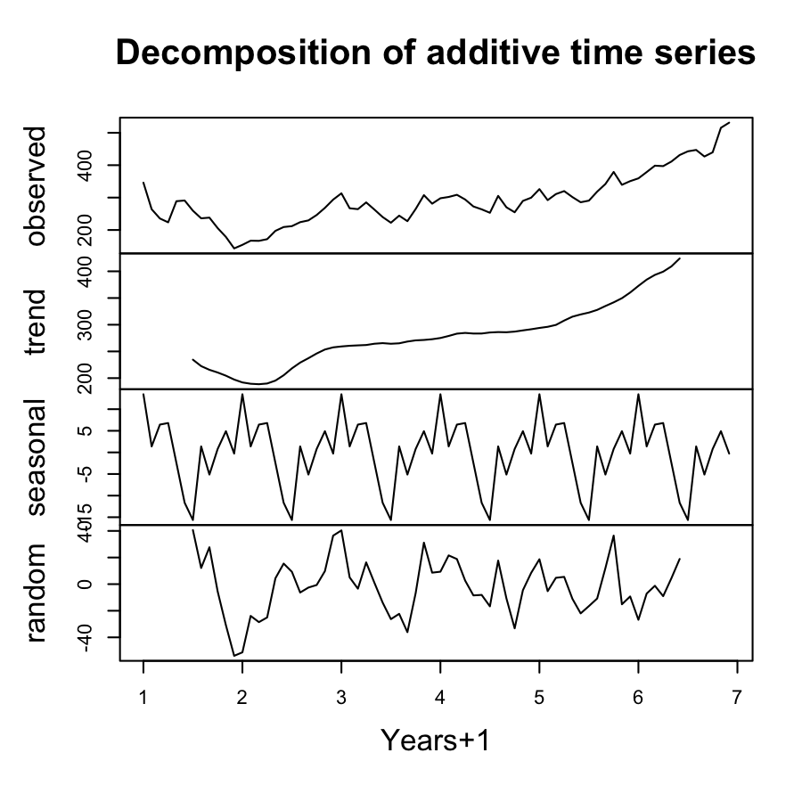

```r
plot(decompose(ts1),xlab="Years+1")
```

## Training and test sets

```r
ts1Train <- window(ts1,start=1,end=5)
ts1Test <- window(ts1,start=5,end=(7-0.01))
ts1Train
```

```
    Jan   Feb   Mar   Apr   May   Jun   Jul   Aug   Sep   Oct   Nov   Dec
1 346.1 264.1 235.5 223.7 288.9 291.0 259.5 236.0 238.2 205.9 178.6 143.2
2 154.2 167.0 166.5 171.7 197.3 209.2 211.9 224.2 229.6 246.2 268.3 293.8
3 313.2 267.0 264.3 285.2 263.0 240.0 222.4 244.2 227.3 264.7 307.6 281.2
4 297.9 301.9 308.6 294.1 272.6 263.8 253.1 305.3 270.1 254.7 289.8 299.7
5 326.1
```

## Simple moving average

$Y_{t}=\frac{1}{2*k+1}\sum_{j=-k}^k {y_{t+j}}$

Th `ma()` funciton is from the ’forecast` package.

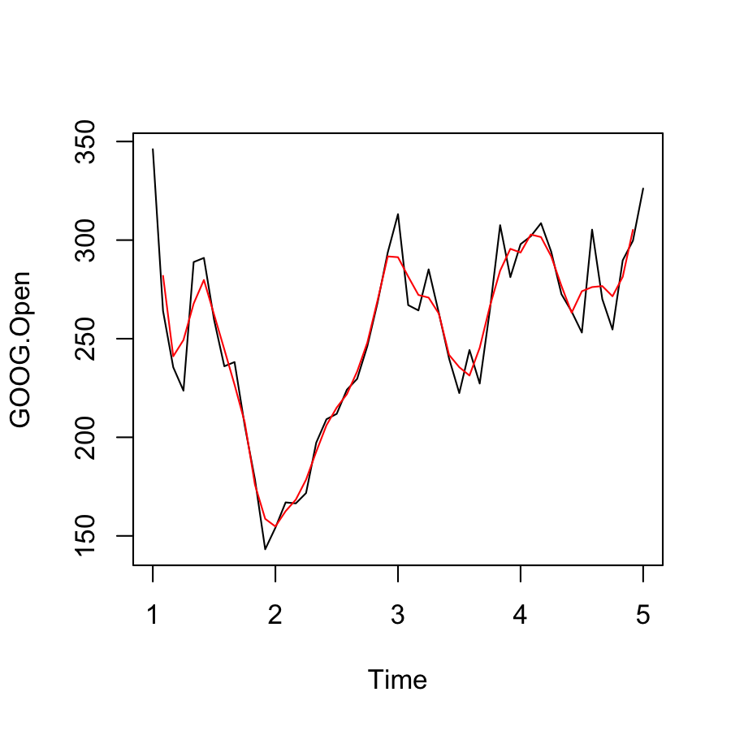

```r
library(forecast)
plot(ts1Train)
lines(ma(ts1Train,order=3),col="red")
```

## Exponential smoothing

**Example - simple exponential smoothing** $\hat{y}_{t+1} = \alpha y_t + (1-\alpha)\hat{y}_{t-1}$

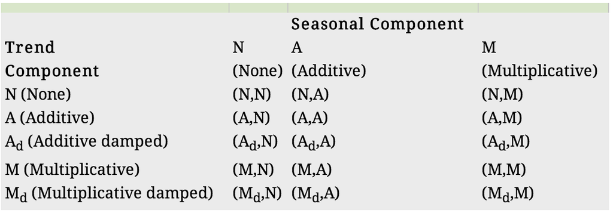

https://www.otexts.org/fpp/7/6

## Exponential smoothing

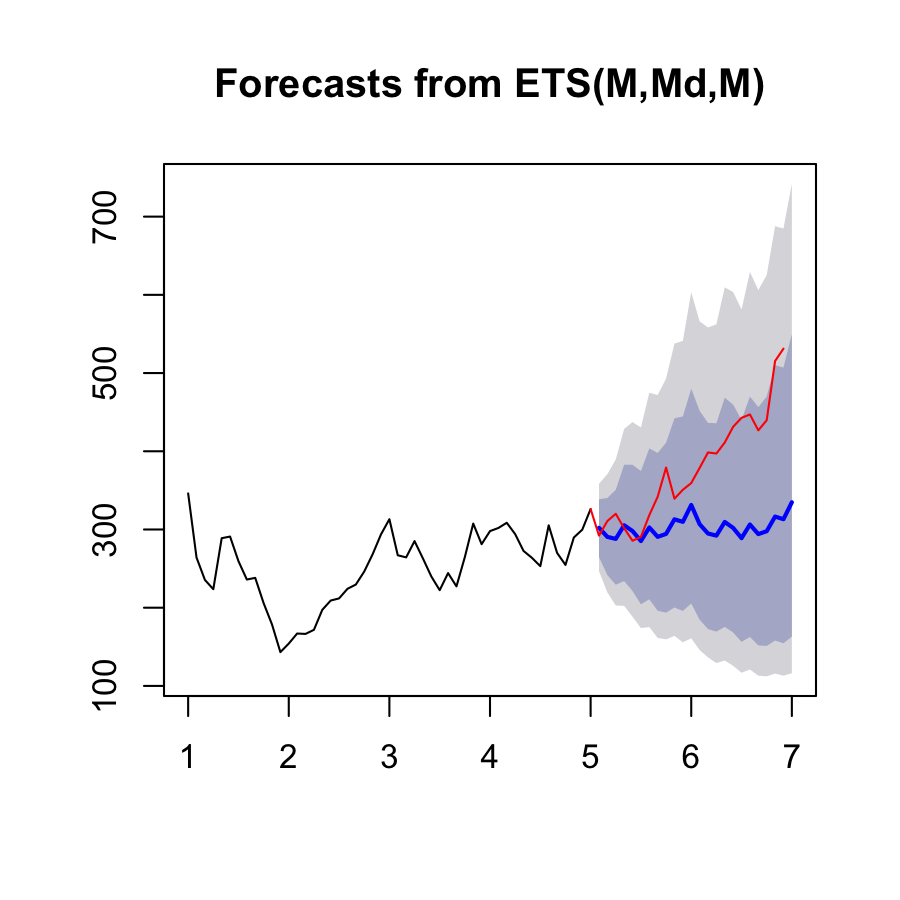

```r
ets1 <- ets(ts1Train,model="MMM")
fcast <- forecast(ets1)
plot(fcast); lines(ts1Test,col="red")
```

## Get the accuracy

```r
accuracy(fcast,ts1Test)
```

```
                  ME   RMSE  MAE     MPE   MAPE   MASE   ACF1 Theil's U
Training set -0.4053  24.07 19.4 -0.6994  7.867 0.5123     NA        NA
Test set     77.2247 101.56 79.5 18.0113 18.796 1.5101 0.7766     3.705
```

## Notes and further resources

- [Forecasting and timeseries prediction](http://en.wikipedia.org/wiki/Forecasting) is an entire field
- Rob Hyndman’s [Forecasting: principles and practice](https://www.otexts.org/fpp/) is a good place to start
- Cautions
- Be wary of spurious correlations
- Be careful how far you predict (extrapolation)
- Be wary of dependencies over time
- See [quantmod](http://cran.r-project.org/web/packages/quantmod/quantmod.pdf) or [quandl](http://www.quandl.com/help/packages/r) packages for finance-related problems.